# Re-Analysis of GSE20104 - ATF4 Overexpression Muscles

Dave Bridges

February 7, 2022

This is generated via GEO2R. Ignored fed and fasted mice

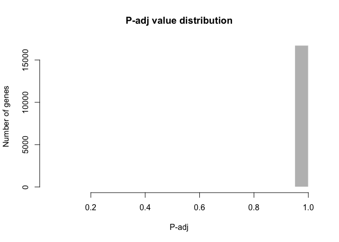

```r
# Version info: R 3.2.3, Biobase 2.30.0, GEOquery 2.40.0, limma 3.26.8
################################################################
#   Differential expression analysis with limma
library(GEOquery)
library(limma)
library(umap)

# load series and platform data from GEO

gset <- getGEO("GSE20104", GSEMatrix =TRUE, AnnotGPL=FALSE)
if (length(gset) > 1) idx <- grep("GPL6096", attr(gset, "names")) else idx <- 1
gset <- gset[[idx]]

# make proper column names to match toptable
fvarLabels(gset) <- make.names(fvarLabels(gset))

# group membership for all samples
gsms <- "01010101XXXXXXXX"
sml <- strsplit(gsms, split="")[[1]]

# filter out excluded samples (marked as "X")
sel <- which(sml != "X")
sml <- sml[sel]
gset <- gset[ ,sel]

# log2 transformation
ex <- exprs(gset)
qx <- as.numeric(quantile(ex, c(0., 0.25, 0.5, 0.75, 0.99, 1.0), na.rm=T))
LogC <- (qx[5] > 100) ||
          (qx[6]-qx[1] > 50 && qx[2] > 0)
if (LogC) { ex[which(ex <= 0)] <- NaN
  exprs(gset) <- log2(ex) }

# assign samples to groups and set up design matrix
gs <- factor(sml)
groups <- make.names(c("Control","ATF4 OE"))
levels(gs) <- groups
gset$group <- gs
gs <- relevel(gs, ref="Control")
design <- model.matrix(~group + 0, gset)
colnames(design) <- levels(gs)

fit <- lmFit(gset, design)  # fit linear model

# set up contrasts of interest and recalculate model coefficients
cts <- paste(groups[2], groups[1], sep="-")
cont.matrix <- makeContrasts(contrasts=cts, levels=design)
fit2 <- contrasts.fit(fit, cont.matrix)

# compute statistics and table of top significant genes
fit2 <- eBayes(fit2, 0.01)
tT <- topTable(fit2, adjust="fdr", sort.by="B", number=250)

tT <- subset(tT, select=c("ID","adj.P.Val","P.Value","t","B","logFC","GB_LIST","SPOT_ID","RANGE_GB","RANGE_STRAND","RANGE_START"))
#write.table(tT, file=stdout(), row.names=F, sep="\t")

# Visualize and quality control test results.
# Build histogram of P-values for all genes. Normal test
# assumption is that most genes are not differentially expressed.
tT2 <- topTable(fit2, adjust="fdr", sort.by="B", number=Inf) %>%
  separate(gene_assignment, into=c('Genbank','Gene.symbol','Gene Name','Other'),
           sep=" // ",
           extra="merge")
hist(tT2$adj.P.Val, col = "grey", border = "white", xlab = "P-adj",
  ylab = "Number of genes", main = "P-adj value distribution")
```

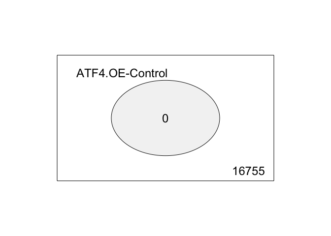

```r
# summarize test results as "up", "down" or "not expressed"
dT <- decideTests(fit2, adjust.method="fdr", p.value=0.05)

# Venn diagram of results
vennDiagram(dT, circle.col=palette())
```

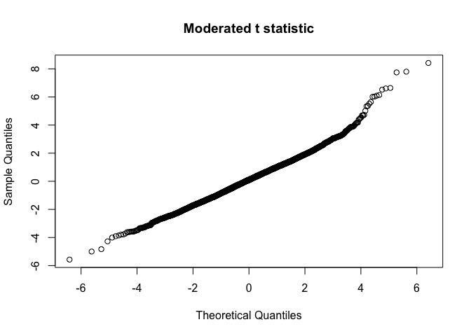

```r
# create Q-Q plot for t-statistic
t.good <- which(!is.na(fit2$F)) # filter out bad probes
qqt(fit2$t[t.good], fit2$df.total[t.good], main="Moderated t statistic")
```

```r
# volcano plot (log P-value vs log fold change)
colnames(fit2) # list contrast names
```

[1] “ATF4.OE-Control”

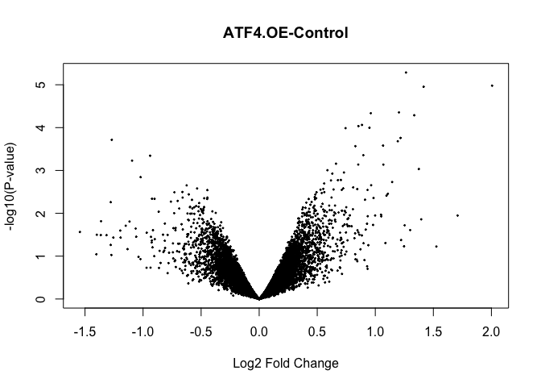

```r
ct <- 1        # choose contrast of interest
volcanoplot(fit2, coef=ct, main=colnames(fit2)[ct], pch=20,
  highlight=length(which(dT[,ct]!=0)), names=rep('+', nrow(fit2)))
```

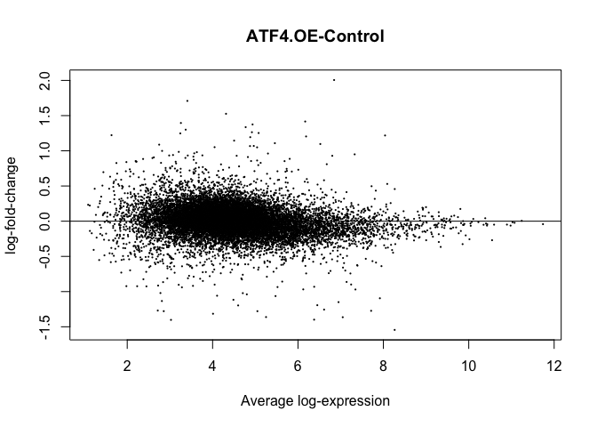

```r
# MD plot (log fold change vs mean log expression)
# highlight statistically significant (p-adj < 0.05) probes
plotMD(fit2, column=ct, status=dT[,ct], legend=F, pch=20, cex=1)
abline(h=0)
```

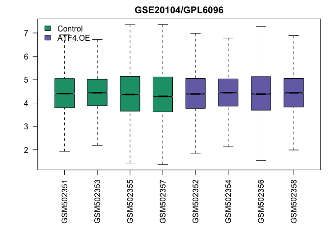

```r
################################################################
# General expression data analysis
ex <- exprs(gset)

# box-and-whisker plot
ord <- order(gs)  # order samples by group
palette(c("#1B9E77", "#7570B3", "#E7298A", "#E6AB02", "#D95F02",
          "#66A61E", "#A6761D", "#B32424", "#B324B3", "#666666"))
par(mar=c(7,4,2,1))
title <- paste ("GSE20104", "/", annotation(gset), sep ="")
boxplot(ex[,ord], boxwex=0.6, notch=T, main=title, outline=FALSE, las=2, col=gs[ord])
legend("topleft", groups, fill=palette(), bty="n")
```

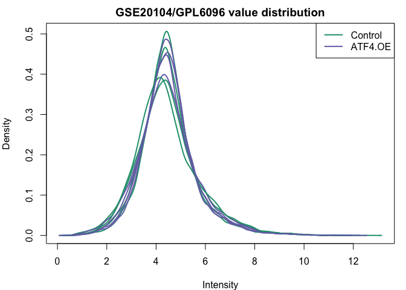

```r
# expression value distribution
par(mar=c(4,4,2,1))
title <- paste ("GSE20104", "/", annotation(gset), " value distribution", sep ="")
plotDensities(ex, group=gs, main=title, legend ="topright")
```

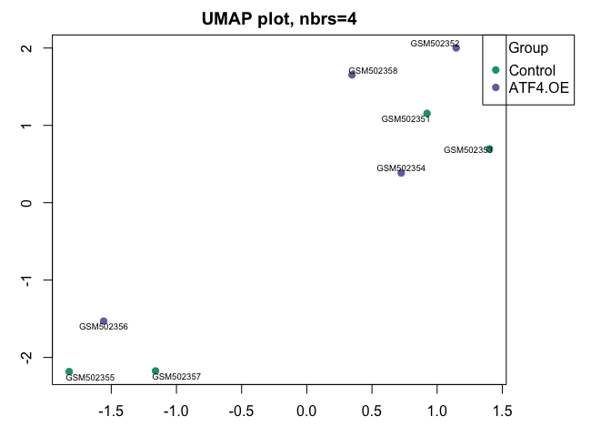

```r
# UMAP plot (dimensionality reduction)
ex <- na.omit(ex) # eliminate rows with NAs
ex <- ex[!duplicated(ex), ]  # remove duplicates
ump <- umap(t(ex), n_neighbors = 4, random_state = 123)
par(mar=c(3,3,2,6), xpd=TRUE)
plot(ump$layout, main="UMAP plot, nbrs=4", xlab="", ylab="", col=gs, pch=20, cex=1.5)
legend("topright", inset=c(-0.15,0), legend=levels(gs), pch=20,
col=1:nlevels(gs), title="Group", pt.cex=1.5)
library("maptools")  # point labels without overlaps
pointLabel(ump$layout, labels = rownames(ump$layout), method="SANN", cex=0.6)
```

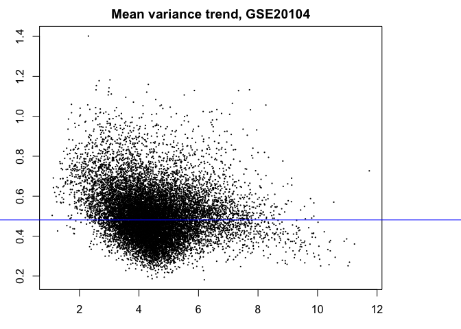

```r
# mean-variance trend, helps to see if precision weights are needed
plotSA(fit2, main="Mean variance trend, GSE20104")
```

```r
#write to output file
output_file <- 'GSE20104 Analysis.tsv'
write.fit(fit2, file=output_file, adjust='BH')

atf4.oe.results <- droplevels(topTable(fit2, n=Inf, adjust.method="BH")) %>%
  separate(gene_assignment, into=c('Genbank','Gene.symbol','Gene Name','Other'),
           sep=" // ",
           extra="merge") %>%
  select(Gene.symbol,logFC,P.Value,adj.P.Val) %>%
  distinct(Gene.symbol, .keep_all=T)
#annotate the probes
sig.atf4.oe.results <- atf4.oe.results %>% filter(P.Value<0.05)
sig.atf4.oe.genes <- sig.atf4.oe.results$Gene.symbol#used nominal p value, nothing sig after FDR

sig.atf4.oe.results.up <- atf4.oe.results %>% filter(P.Value<0.05&logFC>0)#used nominal p value, nothing sig after FDR
sig.atf4.oe.genes.up <- sig.atf4.oe.results.up$Gene.symbol

sig.atf4.oe.results.down <- atf4.oe.results %>% filter(P.Value<0.05&logFC<0)#used nominal p value, nothing sig after FDR
sig.atf4.oe.genes.down <- sig.atf4.oe.results.down$Gene.symbol

mTsc.datafile <- '../RNAseq/Muscle Tsc1 Knockout/data/processed/Binary DESeq Results.csv'
mtsc.data <- read.csv(mTsc.datafile)

sig.mtsc.data <- droplevels(subset(mtsc.data, padj<0.05))
sig.mtsc.data.up <- droplevels(subset(mtsc.data, padj<0.05&log2FoldChange>0))
sig.mtsc.data.down <- droplevels(subset(mtsc.data, padj<0.05&log2FoldChange<0))

sig.mtsc.genes <- sig.mtsc.data$external_gene_name
sig.mtsc.genes.up <- sig.mtsc.data.up$external_gene_name
sig.mtsc.genes.down <- sig.mtsc.data.down$external_gene_name

sig.overlap <- intersect(sig.atf4.oe.genes, sig.mtsc.genes)
sig.overlap.up <- intersect(sig.atf4.oe.genes.up, sig.mtsc.genes.up)
sig.overlap.down <- intersect(sig.atf4.oe.genes.down, sig.mtsc.genes.down)

fisher.table <-
  matrix(c(length(unique(sig.atf4.oe.genes)),
           length(unique(atf4.oe.results$Gene.symbol)),
           length(sig.overlap),
           dim(sig.mtsc.data)[1]),
       nrow = 2,
       dimnames = list(KD.Sig = c("Sig", "Total"),
                       mTSC.Sig = c("ATF4", "mTSC")))

kable(fisher.table, caption="Contingency table for comparason of ATF4 and mTSC, all genes")
```

Contingency table for comparason of ATF4 and mTSC, all genes

|  | ATF4 | mTSC |
| --- | --- | --- |
| Sig | 598 | 153 |
| Total | 16481 | 4403 |

```r
fisher.table.up <-
  matrix(c(length(unique(sig.atf4.oe.genes.up)),
           length(unique(atf4.oe.results$Gene.symbol)),
           length(sig.overlap.up),
           dim(sig.mtsc.data)[1]),
       nrow = 2,
       dimnames = list(KD.Sig = c("Sig", "Total"),
                       mTSC.Sig = c("ATF4", "mTSC")))

kable(fisher.table.up, caption="Contingency table for comparason of ATF4 and mTSC, up-regulated genes")
```

Contingency table for comparason of ATF4 and mTSC, up-regulated genes

|  | ATF4 | mTSC |
| --- | --- | --- |
| Sig | 352 | 69 |
| Total | 16481 | 4403 |

```r
fisher.table.down <-
  matrix(c(length(unique(sig.atf4.oe.genes.down)),
           length(unique(atf4.oe.results$Gene.symbol)),
           length(sig.overlap.down),
           dim(sig.mtsc.data)[1]),
       nrow = 2,
       dimnames = list(KD.Sig = c("Sig", "Total"),
                       mTSC.Sig = c("ATF4", "mTSC")))

kable(fisher.table.down, caption="Contingency table for comparason of ATF4 and mTSC, down-regulated genes")
```

Contingency table for comparason of ATF4 and mTSC, down-regulated genes

|  | ATF4 | mTSC |
| --- | --- | --- |
| Sig | 246 | 57 |
| Total | 16481 | 4403 |

This identified 598 significantly differentially expressed genes in their analysis out of a total of 16481 genes assessed. Of these differentially expressed genes. 153 genes overlapped with our 4403 significantly different genes from *Tsc1* knockout mice quadriceps. This is an insignificant level of overlap (1.044 fold enrichment; p=0.682).

```r
combined.genes <-
  mtsc.data %>%
  select(external_gene_name,log2FoldChange,pvalue,padj) %>%
  left_join(atf4.oe.results, by=c('external_gene_name'='Gene.symbol')) %>%
  rename("log2FC_TSC"="log2FoldChange",
         "pval_TSC"='pvalue',
         "padj_TSC"='padj',
         "log2FC_KD"="logFC",
         'pval_KD'="P.Value",
         'padj_KD'='adj.P.Val')

with(combined.genes, lm(log2FC_TSC~log2FC_KD))  %>% tidy %>% kable(caption="Linear model for association between ATF4 fold change and TSC fold change")
```

Linear model for association between ATF4 fold change and TSC fold change

| term | estimate | std.error | statistic | p.value |
| --- | --- | --- | --- | --- |
| (Intercept) | 0.113 | 0.007 | 15.3 | 0 |
| log2FC_KD | 0.688 | 0.039 | 17.6 | 0 |

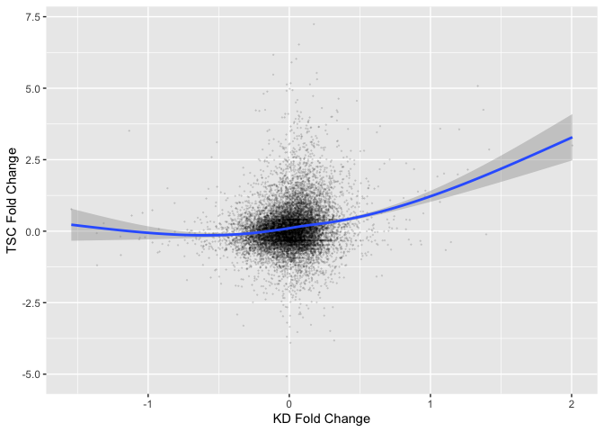

```r
library(ggplot2)
combined.genes %>%
  ggplot(aes(y=log2FC_TSC,x=log2FC_KD)) +
  geom_point(size=0.1, alpha=0.1) +
  labs(y="TSC Fold Change",x="KD Fold Change") +
  geom_smooth(se=T)
```

```r
interesting.genes <- c('Sln','Gdf15') #
combined.genes %>%
  filter(external_gene_name %in% interesting.genes) %>%
  kable(caption="Selected genes")
```

Selected genes

| external_gene_name | log2FC_TSC | pval_TSC | padj_TSC | log2FC_KD | pval_KD | padj_KD |
| --- | --- | --- | --- | --- | --- | --- |
| Gdf15 | 5.53 | 0 | 0 | 0.195 | 0.457 | 1.000 |
| Sln | 4.25 | 0 | 0 | 1.375 | 0.001 | 0.707 |

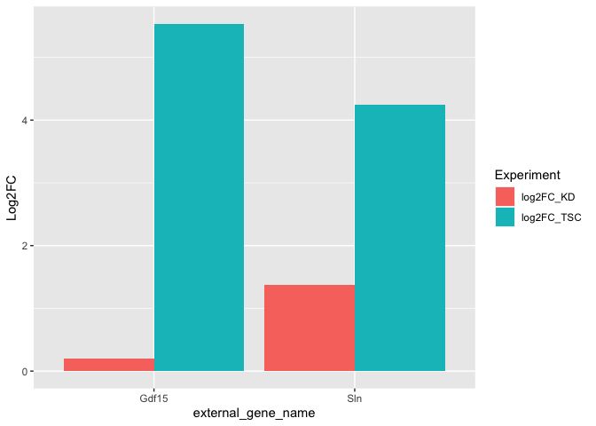

```r
combined.genes %>%
  filter(external_gene_name %in% interesting.genes) %>%
  select(external_gene_name, log2FC_KD, log2FC_TSC) %>%
  group_by(external_gene_name) %>%
  pivot_longer(names_to = 'Experiment', values_to = 'Log2FC', cols=log2FC_KD:log2FC_TSC) %>%
  ggplot(aes(y=Log2FC,x=external_gene_name,
             fill=Experiment)) +
    geom_bar(stat='identity', position='dodge')
```

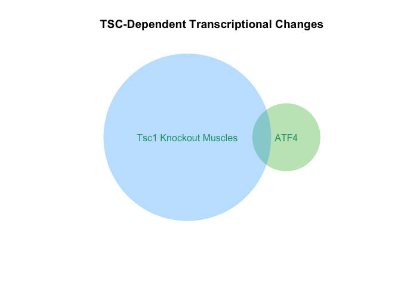

```r
require(venneuler)
v.diseases <- venneuler(c("ATF4"=length(sig.atf4.oe.genes),
                 "Tsc1 Knockout Muscles"=length(sig.mtsc.genes),
                 "ATF4&Tsc1 Knockout Muscles"=length(intersect(sig.atf4.oe.genes, sig.mtsc.genes))))

v.diseases.up <- venneuler(c("ATF4"=length(sig.atf4.oe.genes.up),
                 "Tsc1 Knockout Muscles"=length(sig.mtsc.genes.up),
                 "ATF4&Tsc1 Knockout Muscles"=length(intersect(sig.atf4.oe.genes.up, sig.mtsc.genes.up))))
v.diseases.down <- venneuler(c("ATF4"=length(sig.atf4.oe.genes.down),
                 "Tsc1 Knockout Muscles"=length(sig.mtsc.genes.down),
                 "ATF4&Tsc1 Knockout Muscles"=length(intersect(sig.atf4.oe.genes.down, sig.mtsc.genes.down))))

plot(v.diseases, main="TSC-Dependent Transcriptional Changes")
```

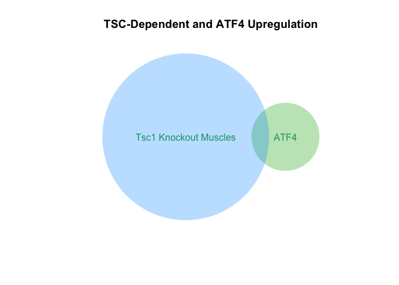

```r
plot(v.diseases.up, main="TSC-Dependent and ATF4 Upregulation")
```

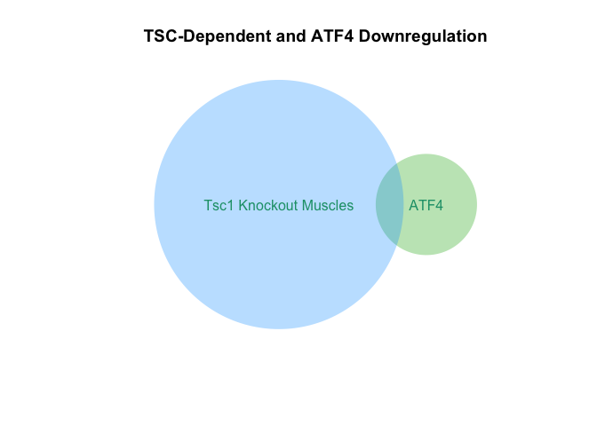

```r
plot(v.diseases, main="TSC-Dependent and ATF4 Downregulation")
```

```r
# library(Vennerable)
# v.list <- list(`Tsc2 Knockout MEFs` = sig.duvel.genes, `Tsc1 Knockout Muscles` = sig.mtsc.genes)
# v.data <- Venn(v.list)
# plot(v.data)
```

# Pathway Analysis

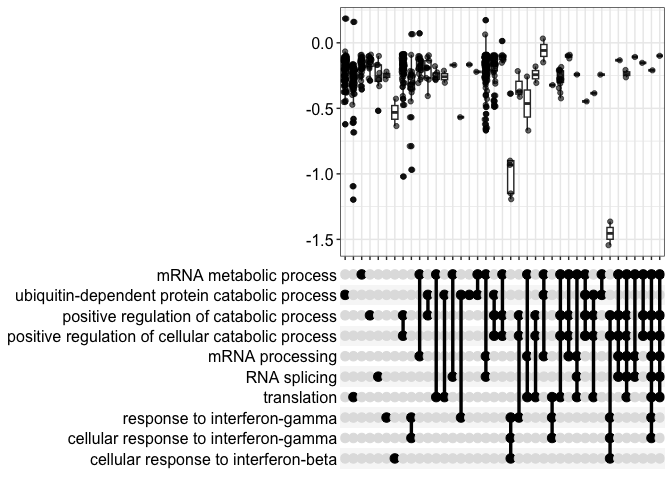

```r
library(clusterProfiler)
library(org.Mm.eg.db)
db.db.logfc <-
  tT2 %>%
  arrange(-logFC) %>%
  dplyr::select(logFC, Gene.symbol)

db.db.list <- as.numeric(db.db.logfc$logFC)
names(db.db.list) <- db.db.logfc$Gene.symbol
gsea.bp <- gseGO(db.db.list,
             ont ="BP",
             keyType = "SYMBOL",
             OrgDb = org.Mm.eg.db)
library(enrichplot)
upsetplot(gsea.bp)
```

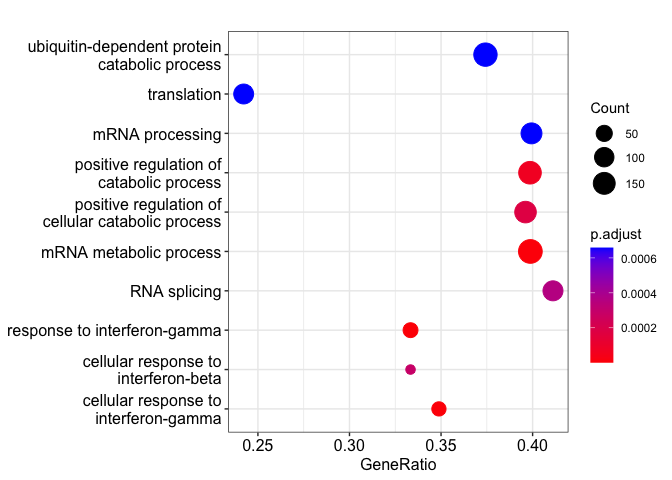

```r
dotplot(gsea.bp, orderBy="NES")
```

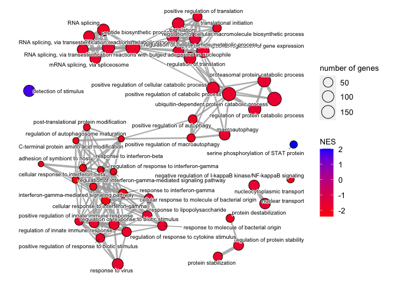

```r
gsea.bp <- pairwise_termsim(gsea.bp, method="JC")
emapplot(gsea.bp,
         cex_label_category=0.5,
         showCategory = 50,
         color="NES",
         min_edge=0.1)
```

```r
gsea.bp %>% as.data.frame %>% dplyr::select(NES,pvalue,p.adjust,Description, core_enrichment) %>% arrange(-NES) %>% filter(p.adjust<0.05) %>% kable(caption="Significant GO-BP pathways")
```

Significant GO-BP pathways

|  | NES | pvalue | p.adjust | Description | core_enrichment |
| --- | --- | --- | --- | --- | --- |
| GO:0042501 | 2.01 | 0.000 | 0.016 | serine phosphorylation of STAT protein | Ifnz/Ifna14/Gadd45a/Ifna13/Ifna2/Ifnb1/Ifna11/Ifna9/Ifna12/Gfra2/Il24/Ifng/Ifna4 |
| GO:0033139 | 2.00 | 0.000 | 0.027 | regulation of peptidyl-serine phosphorylation of STAT protein | Ifnz/Ifna14/Gadd45a/Ifna13/Ifna2/Ifnb1/Ifna11/Ifna9/Ifna12/Gfra2 |
| GO:0033141 | 1.98 | 0.000 | 0.031 | positive regulation of peptidyl-serine phosphorylation of STAT protein | Ifnz/Ifna14/Ifna13/Ifna2/Ifnb1/Ifna11/Ifna9/Ifna12/Gfra2/Ifng/Ifna4/Ifna6 |
| GO:0003009 | 1.96 | 0.000 | 0.028 | skeletal muscle contraction | Tnni1/Tnnc1/Chrna1/Chrnb1/Chrnd/Cav3/Chrng |
| GO:0071294 | 1.96 | 0.001 | 0.044 | cellular response to zinc ion | Mt1/Gabrb3/Glra2/Gpr39/Mt4/Mt3 |
| GO:0034377 | 1.95 | 0.000 | 0.022 | plasma lipoprotein particle assembly | Apoe/Abca1/Arf1/Soat1/Apoa4/Apoa2 |
| GO:0071514 | 1.94 | 0.001 | 0.046 | genomic imprinting | H19/Zfp42/Cdkn1c/Meg3/Dppa3/a/Ndn |
| GO:0051606 | 1.69 | 0.000 | 0.011 | detection of stimulus | Tas2r140/Tas2r105/Csrp3/Olfr15/Tas2r143/Tas2r106/Reep6/Tas2r…… |
| GO:0030198 | 1.58 | 0.000 | 0.021 | extracellular matrix organization | Grem1/Col14a1/Fn1/Mmp12/Wnt3a/Adamts5/Lgals3/Sh3pxd2b/Postn/…… |
| GO:0043062 | 1.58 | 0.000 | 0.036 | extracellular structure organization | Grem1/Col14a1/Fn1/Mmp12/Wnt3a/Adamts5/Lgals3/Sh3pxd2b/Postn/…… |
| GO:0045229 | 1.55 | 0.000 | 0.036 | external encapsulating structure organization | Grem1/Col14a1/Fn1/Mmp12/Wnt3a/Adamts5/Lgals3/Sh3pxd2b/Postn/…… |
| GO:0006281 | -1.44 | 0.000 | 0.032 | DNA repair | Hus1/Poli/Aplf/Ruvbl2/Pold2/Rif1/Fh1/Parp1/Fignl1/Ppp4r2/Nip…… |
| GO:0034660 | -1.46 | 0.000 | 0.037 | ncRNA metabolic process | Rpl10a/Osgepl1/Trmt11/Grsf1/Exosc9/Mybl1/Thumpd3/Nol11/Rpp30…… |
| GO:0043161 | -1.49 | 0.000 | 0.033 | proteasome-mediated ubiquitin-dependent protein catabolic process | Fbxo45/Styx/Rnf19a/Hace1/Rchy1/Nkd2/Rnf126/Fbxo31/Chfr/Fbxw1…… |
| GO:0048872 | -1.50 | 0.000 | 0.019 | homeostasis of number of cells | Smarca2/Rb1/Vhl/Inhba/Ezh1/Csf1/Ppp2r3c/Il2ra/Ccnb2/Pla2g10/…… |
| GO:0022613 | -1.53 | 0.000 | 0.027 | ribonucleoprotein complex biogenesis | Clns1a/Rsl1d1/Prpf8/Mbnl1/Pten/Utp20/Eif2a/Atm/Sdad1/Ddx47/E…… |
| GO:2000112 | -1.53 | 0.000 | 0.011 | regulation of cellular macromolecule biosynthetic process | Nck1/Qk/Il15/Ppp1r15b/Bzw1/Eif5a/Tmem59/Mrpl13/Eif5/Etf1/Tsc…… |
| GO:0006913 | -1.55 | 0.000 | 0.013 | nucleocytoplasmic transport | Kpna4/Ranbp2/Efcab7/Xpo1/Ptgs2/Rab23/Nup160/Nup155/Pkia/Anp3…… |
| GO:0051169 | -1.55 | 0.000 | 0.013 | nuclear transport | Kpna4/Ranbp2/Efcab7/Xpo1/Ptgs2/Rab23/Nup160/Nup155/Pkia/Anp3…… |
| GO:0042176 | -1.56 | 0.000 | 0.012 | regulation of protein catabolic process | Ophn1/Foxo1/Snx9/Arntl/Vps35/Rgn/Pias1/Sec22b/Egf/Nfe2l1/Sty…… |
| GO:0043043 | -1.57 | 0.000 | 0.002 | peptide biosynthetic process | Nck1/Yars2/Qk/Gclc/Eif4b/Ppp1r15b/Bzw1/Eif5a/Mrpl13/Eif5/Etf…… |
| GO:0006511 | -1.60 | 0.000 | 0.001 | ubiquitin-dependent protein catabolic process | Rnf19a/Pten/Hace1/Rchy1/Rnf114/Nkd2/Rnf126/Fbxo31/Chfr/Fbxw1…… |
| GO:0034248 | -1.60 | 0.000 | 0.005 | regulation of cellular amide metabolic process | Ppp1r15b/Bzw1/Eif5a/Mrpl13/Eif5/Etf1/Tsc1/Hbs1l/Pdk4/Dph3/Ro…… |
| GO:0010608 | -1.61 | 0.000 | 0.003 | post-transcriptional regulation of gene expression | Tnrc6a/Aco1/Ilf3/Itga2/Xpo5/Mettl5/Dhx36/Ireb2/Prkca/Per2/Me…… |
| GO:0000209 | -1.62 | 0.000 | 0.025 | protein polyubiquitination | Rnf19a/Hace1/Rnf114/Rnf126/Chfr/Fbxw11/Ube2q1/Rnf135/Trim44/…… |
| GO:0002262 | -1.63 | 0.000 | 0.033 | myeloid cell homeostasis | Pla2g10/Exoc6/Sp3/Rhag/Rps24/Ncor1/Itgam/Ccr2/Cdk5rap3/Lyn/B…… |
| GO:0010498 | -1.63 | 0.000 | 0.001 | proteasomal protein catabolic process | Kcne2/Rnf19a/Hace1/Rchy1/Nkd2/Rnf126/Fbxo31/Chfr/Fbxw11/Psma…… |
| GO:0009615 | -1.63 | 0.000 | 0.008 | response to virus | Oas1a/Bcl2l1/Ifnar2/Polr3f/Ikbke/Ifitm7/Smpd1/Hyal1/Cd40/Tri…… |
| GO:0006412 | -1.64 | 0.000 | 0.001 | translation | Nck1/Yars2/Qk/Eif4b/Ppp1r15b/Bzw1/Eif5a/Mrpl13/Eif5/Etf1/Rps…… |
| GO:0071216 | -1.65 | 0.000 | 0.019 | cellular response to biotic stimulus | Tlr2/Adam9/Txnip/Cd80/Cd86/Atg10/Ppp1r15b/Nfkb1/Cdc73/Casp1/…… |

[output cut: 52 more lines]

## Empirical Muscle ATF4 Gene Set

```r
list(ATF4q0.25 = tT2 %>% filter(adj.P.Val <0.25) %>% pull(Gene.symbol),
     ATF4p0.001 = tT2 %>% filter(P.Value <0.001) %>% pull(Gene.symbol),
     ATF4p0.01 = tT2 %>% filter(P.Value <0.01) %>% pull(Gene.symbol),
     ATF4p0.05 = tT2 %>% filter(P.Value <0.05) %>% pull(Gene.symbol)) -> atf4.gene.lists
library(fgsea)

mtsc.ranks <- pull(mtsc.data, log2FoldChange)
names(mtsc.ranks) <- mtsc.data$external_gene_name

mtsc.atf4.pathways <- fgsea(pathways = atf4.gene.lists,
                  stats    = sort(mtsc.ranks,decreasing=T),
                  minSize  = 1,
                  maxSize  = 500)

mtsc.atf4.pathways %>%
  arrange(-NES) %>%
  kable(caption="GSEA results for mTSC differential expression results compared to empirically determined ATF4 dependent changes in muscle")
```

GSEA results for mTSC differential expression results compared to empirically determined ATF4 dependent changes in muscle

| pathway | pval | padj | log2err | ES | NES | size | leadingEdge |
| --- | --- | --- | --- | --- | --- | --- | --- |
| ATF4p0.001 | 0.000 | 0.000 | 0.611 | 0.855 | 2.06 | 15 | Uchl1, S…. |
| ATF4p0.01 | 0.000 | 0.000 | 0.675 | 0.612 | 2.04 | 86 | Uchl1, S…. |
| ATF4q0.25 | 0.001 | 0.001 | 0.455 | 0.862 | 1.80 | 8 | Uchl1, A…. |
| ATF4p0.05 | 0.000 | 0.000 | 0.557 | 0.401 | 1.53 | 410 | Uchl1, S…. |

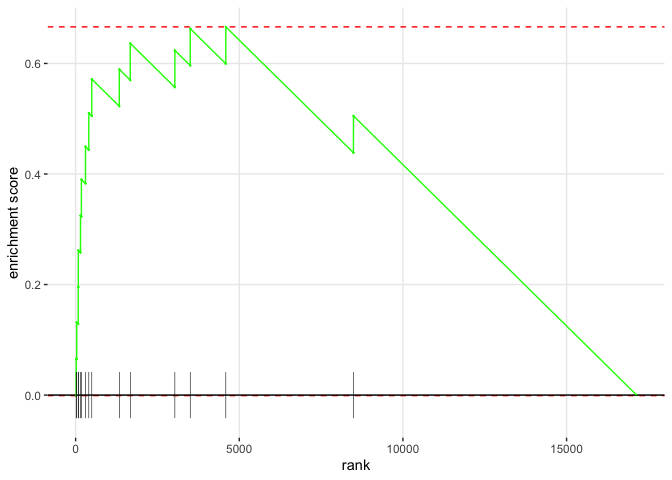

```r
plotEnrichment(atf4.gene.lists[["ATF4p0.001"]],
               !(is.na(sort(mtsc.ranks, decreasing=T))))
```

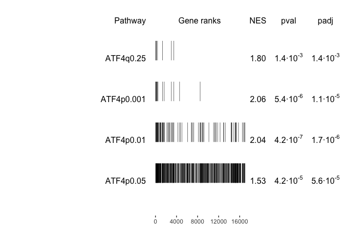

```r
plotGseaTable(atf4.gene.lists, !(is.na(sort(mtsc.ranks,decreasing=T))), mtsc.atf4.pathways,
              gseaParam=0.5)
```

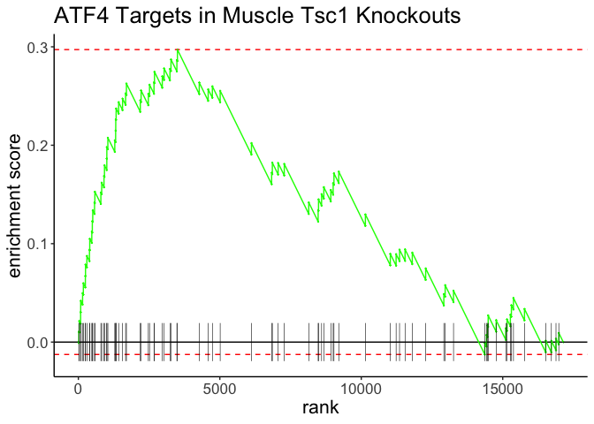

```r
plotEnrichment(atf4.gene.lists[["ATF4p0.01"]],
               !(is.na(sort(mtsc.ranks, decreasing=T)))) +
  labs(title="ATF4 Targets in Muscle Tsc1 Knockouts") +
  theme_classic() +
  theme(text=element_text(size=16))
```

## Pathway Analysis of Dual TSC/ATF4 Genes

The co-regulated genes in TSC and ATF4 muscles were:

*Upregulated*: Tnni1, Myl4, Tnnt2, Ankrd1, Igf2, Uchl1, Apoe, Asns, Chrna1, Slc7a5, Krt18, Sln, Nes, Csrp3, Tmem37, Ncam1, Casq2, Kcnn3, Tnnc1, Chrnd, Cyb5r3, Cth, Zfp697, Gadd45a, Maged2, Hspb7, Txndc2, Carhsp1, Psat1, Chrnb1, Myog, Dclk1, Lypd1, Grb10, Gars, Cib1, Kcnv2, Pcbd1, Uck2, Gamt, Mustn1, Rnd2, Rassf3, Dusp6, C1qtnf3, Fam171b, Bin3, Rab15, Hspa2, Tal2, Lrrn1, Xirp1, Cdca4, Nt5c2, Snap47, Iah1, Ift122, Tubb6, Hspa4l, Nefm, Tubb3, Usp11, 6430548M08Rik, Meox1, Ttf2, Nol3, Htatip2, Gck, Tceal5

*Downregulated*:Asb14, Rbmx, Tubd1, Ppp1r1a, Serpine2, Bcap29, Ppp3cb, Ostn, Dcun1d2, Tmem56, Gbp4, March7, Ankrd46, Rgs5, Hnrnpa2b1, Eif3f, Smyd2, Rpap3, Tek, Hook1, Sdr39u1, Lpin1, Mapk9, Strbp, Chd7, Pptc7, Cdkal1, Sec62, Rpl21, Car14, Atp8a1, Usp10, Fmo2, Gpd2, Cd24a, Scn4b, Trim54, Fam118b, Zfp62, Gbp2, Cep350, Art3, Stat1, 4430402I18Rik, Zfp458, Eif1, Hist2h2be, Nub1, Cmbl, Fam161a, Chad, Kcnf1, Bmi1, Ube2b, Ddx5, Ahctf1, Ccdc91

```r
enrich.bp <- enrichGO(c(sig.overlap.up,sig.overlap.down),
             ont ="BP",
             keyType = "SYMBOL",
             OrgDb = org.Mm.eg.db)
library(enrichplot)
#upsetplot(enrich.bp)
#dotplot(enrich.bp, orderBy="NES")
#enrich.bp <- pairwise_termsim(enrich.bp, method="JC")
# emapplot(enrich.bp,
#          cex_label_category=0.5,
#          showCategory = 50,
#          color="NES",
#          min_edge=0.1)

enrich.bp %>% as.data.frame %>% dplyr::select(GeneRatio,pvalue,p.adjust,Description) %>%  filter(p.adjust<0.05) %>% kable(caption="Significant GO-BP pathways for co-regulated genes")
```

Significant GO-BP pathways for co-regulated genes

|  | GeneRatio | pvalue | p.adjust | Description |
| --- | --- | --- | --- | --- |
| GO:0006941 | 10/119 | 0.000 | 0.000 | striated muscle contraction |
| GO:0060537 | 14/119 | 0.000 | 0.000 | muscle tissue development |
| GO:0003012 | 13/119 | 0.000 | 0.000 | muscle system process |
| GO:0007517 | 12/119 | 0.000 | 0.000 | muscle organ development |
| GO:0006936 | 10/119 | 0.000 | 0.000 | muscle contraction |
| GO:0003009 | 5/119 | 0.000 | 0.000 | skeletal muscle contraction |
| GO:0060048 | 7/119 | 0.000 | 0.000 | cardiac muscle contraction |
| GO:0055001 | 8/119 | 0.000 | 0.001 | muscle cell development |
| GO:0050879 | 5/119 | 0.000 | 0.001 | multicellular organismal movement |
| GO:0050881 | 5/119 | 0.000 | 0.001 | musculoskeletal movement |
| GO:0070296 | 4/119 | 0.000 | 0.002 | sarcoplasmic reticulum calcium ion transport |
| GO:0043462 | 5/119 | 0.000 | 0.002 | regulation of ATP-dependent activity |
| GO:0055008 | 5/119 | 0.000 | 0.002 | cardiac muscle tissue morphogenesis |
| GO:0042692 | 10/119 | 0.000 | 0.002 | muscle cell differentiation |
| GO:0048630 | 3/119 | 0.000 | 0.002 | skeletal muscle tissue growth |
| GO:0095500 | 4/119 | 0.000 | 0.002 | acetylcholine receptor signaling pathway |
| GO:0048738 | 8/119 | 0.000 | 0.002 | cardiac muscle tissue development |
| GO:1905145 | 4/119 | 0.000 | 0.002 | cellular response to acetylcholine |
| GO:0010563 | 10/119 | 0.000 | 0.002 | negative regulation of phosphorus metabolic process |
| GO:0045936 | 10/119 | 0.000 | 0.002 | negative regulation of phosphate metabolic process |
| GO:0007519 | 7/119 | 0.000 | 0.003 | skeletal muscle tissue development |
| GO:1905144 | 4/119 | 0.000 | 0.003 | response to acetylcholine |
| GO:0014706 | 8/119 | 0.000 | 0.003 | striated muscle tissue development |
| GO:0060415 | 5/119 | 0.000 | 0.003 | muscle tissue morphogenesis |
| GO:0060538 | 7/119 | 0.000 | 0.003 | skeletal muscle organ development |
| GO:0042326 | 9/119 | 0.000 | 0.004 | negative regulation of phosphorylation |
| GO:0019932 | 8/119 | 0.000 | 0.004 | second-messenger-mediated signaling |
| GO:0048644 | 5/119 | 0.000 | 0.004 | muscle organ morphogenesis |
| GO:0010677 | 4/119 | 0.000 | 0.004 | negative regulation of cellular carbohydrate metabolic process |
| GO:0045214 | 4/119 | 0.000 | 0.004 | sarcomere organization |

[output cut: 114 more lines]

# Specific Genes

## Sarcolipin

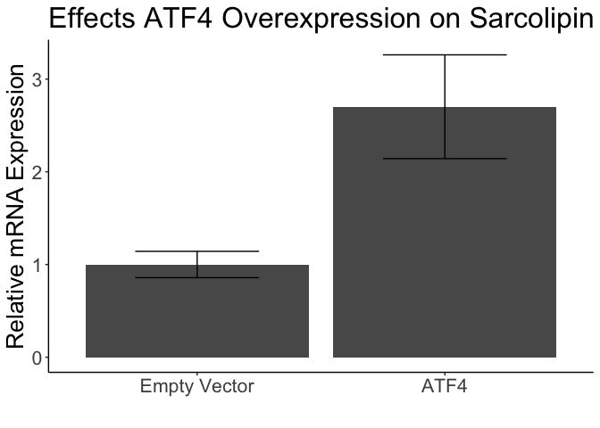

```r
sln.id <- tT2 %>% filter(Gene.symbol=='Sln') %>% rownames()
sln.exprs <- exprs(gset)[sln.id,]

sln.data <- data.frame(sln.exprs, gs)

library(forcats)
sln.data %>%
  group_by(gs) %>%
  summarize(avg=mean(2^sln.exprs),
            error=se(2^sln.exprs)) %>%
  mutate(norm.mean = avg/avg[1],
         norm.error = error/avg[1]) %>%
  ggplot(aes(x=gs,
             y=norm.mean,
             ymin=norm.mean-norm.error,
             ymax=norm.mean+norm.error)) +
  geom_bar(stat='identity', position='dodge') +
  geom_errorbar(width=0.5) +
  scale_x_discrete(labels=c("Control" = "Empty Vector", "ATF4.OE" = "ATF4")) +
  theme_classic() +
  theme(text=element_text(size=20)) +
  labs(y='Relative mRNA Expression',
       x='',
       title='Effects ATF4 Overexpression on Sarcolipin')
```

## TSC Induced Genes

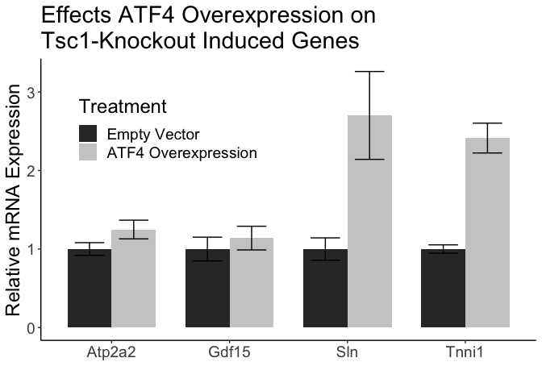

```r
genes.to.test <- c('Sln','Gdf15','Atp2a2', 'Tnni1')
kt.id <- tT2 %>% filter(Gene.symbol%in%genes.to.test) %>% rownames()
kt.exprs <- exprs(gset)[kt.id,]
rownames(kt.exprs) <- tT2[kt.id,'Gene.symbol']

library(tibble)
kt.data <- as.data.frame(kt.exprs) %>%
  rownames_to_column(var="Gene") %>%
  pivot_longer(-Gene, names_to='Sample') %>%
  mutate(Treatment=rep(as.character(gs),dim(kt.exprs)[1]))


library(forcats)
kt.data %>%
  group_by(Gene,Treatment) %>%
  summarize(avg=mean(2^value),
            error=se(2^value)) %>%
  mutate(norm.mean = avg/avg[Treatment=='Control'],
         norm.error = error/avg[Treatment=='Control']) %>%
  mutate(Treatment=fct_recode(as.factor(relevel(as.factor(Treatment),ref="Control")),
                              "Empty Vector"="Control",
                              "ATF4 Overexpression"="ATF4.OE")) %>%
  ggplot(aes(x=Gene,
             fill=Treatment,
             y=norm.mean,
             ymin=norm.mean-norm.error,
             ymax=norm.mean+norm.error)) +
  geom_bar(stat='identity', position='dodge',width=0.75) +
  geom_errorbar(position=position_dodge(width=0.75),width=0.5) +
  #scale_x_discrete(labels=c("Control" = "Empty Vector", "ATF4 Overexpression" = "ATF4")) +
  theme_classic() +
  theme(text=element_text(size=18),
               legend.position=c(0.25,0.75)) +
  scale_fill_grey() +
  labs(y='Relative mRNA Expression',
       x='',
       title='Effects ATF4 Overexpression on \nTsc1-Knockout Induced Genes')
```

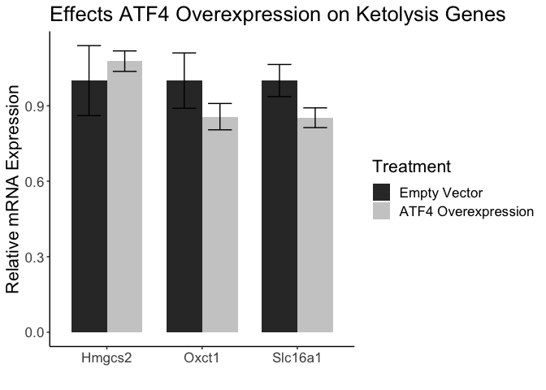

```r
genes.to.test <- c('Slc16a1','Oxct1','Hmgcs2')
kt.id <- tT2 %>% filter(Gene.symbol%in%genes.to.test) %>% rownames()
kt.exprs <- exprs(gset)[kt.id,]
rownames(kt.exprs) <- genes.to.test

kt.data <- as.data.frame(kt.exprs) %>%
  rownames_to_column(var="Gene") %>%
  pivot_longer(-Gene, names_to='Sample') %>%
  mutate(Treatment=rep(as.character(gs),3))


kt.data %>%
  group_by(Gene,Treatment) %>%
  summarize(avg=mean(2^value),
            error=se(2^value)) %>%
  mutate(norm.mean = avg/avg[Treatment=='Control'],
         norm.error = error/avg[Treatment=='Control']) %>%
  mutate(Treatment=fct_recode(as.factor(relevel(as.factor(Treatment),ref="Control")),
                              "Empty Vector"="Control",
                              "ATF4 Overexpression"="ATF4.OE")) %>%
  ggplot(aes(x=Gene,
             fill=Treatment,
             y=norm.mean,
             ymin=norm.mean-norm.error,
             ymax=norm.mean+norm.error)) +
  geom_bar(stat='identity', position='dodge',width=0.75) +
  geom_errorbar(position=position_dodge(width=0.75),width=0.5) +
  #scale_x_discrete(labels=c("Control" = "Empty Vector", "ATF4 Overexpression" = "ATF4")) +
  theme_classic() +
  scale_fill_grey() +
  theme(text=element_text(size=16)) +
  labs(y='Relative mRNA Expression',
       x='',
       title='Effects ATF4 Overexpression on Ketolysis Genes')
```